# Networks day 1 – Coding Lab and Exercises

Alexandra Rottenkolber, with some inspiration from a lab written by José Luis Estévez Navarro

2023-11-20

# Content of this Lab

1. Reading and exploring network data
2. Network descriptives and centrality measures
3. Elementary transformation: dichotomization, transposition, and symmetrization
4. Multiplex & bipartite networks
5. Random networks
- Erdős–Rényi graph
- Watt-Strogatz graph (small world networks)
- Barabasi-Albert graph (preferential attachment model)

# Data management and representation of networks

### Data handling

```r
# 1) READING AND EXPLORING NETWORK DATA

# Information on the data we will use
#browseURL("https://www.stats.ox.ac.uk/~snijders/siena/s50_data.htm")

edges_t1 <- read.csv("./s50_data/s50-network1.dat", header = FALSE, sep = " ") # adjacency matrix of the student network
edges_t1$V1 <- NULL # remove index

node_sport <- read.csv("./s50_data/s50-sport.dat", header = FALSE, sep = " ") # How much sport people do
node_sport$V1 <- NULL # remove index
names(node_sport) <- c("t1", "t2", "t3") # set column names
node_sport["node_id"] <- colnames(edges_t1)

node_alc <- read.csv("./s50_data/s50-alcohol.dat", header = FALSE, sep = " ") # How much people do sports
node_alc$V1 <- NULL # remove index
names(node_alc) <- c("t1", "t2", "t3") # set column names
node_alc["node_id"] <- colnames(edges_t1)
```

```r
# Data exploration
class(node_sport); class(node_alc); class(edges_t1)
```

```
## [1] "data.frame"
```

```
## [1] "data.frame"
```

```
## [1] "data.frame"
```

```r
dim(node_sport); dim(node_alc); dim(edges_t1)
```

```
## [1] 50  4
```

```
## [1] 50  4
```

```
## [1] 50 50
```

```r
head(node_sport) # this is a standard data set, each row represents a person (N = 50)
```

```
##   t1 t2 t3 node_id
## 1  2  1  1      V2
## 2  1  1  1      V3
## 3  1  1  1      V4
## 4  2  2  1      V5
## 5  2  2  2      V6
## 6  2  2  2      V7
```

```r
# For your own analysis it it always good to check for duplicates
# length(unique(nodes$ID)) == nrow(nodes))
colnames(node_sport)
```

```
## [1] "t1"      "t2"      "t3"      "node_id"
```

```r
head(edges_t1) # This is an adjacency matrix (student -> reported friend)
```

```
##   V2 V3 V4 V5 V6 V7 V8 V9 V10 V11 V12 V13 V14 V15 V16 V17 V18 V19 V20 V21 V22
## 1  0  0  0  0  0  0  0  0   0   0   1   0   0   1   0   0   0   0   0   0   0
## 2  0  0  0  0  0  0  1  0   0   0   1   0   0   0   0   0   0   0   0   0   0
## 3  0  0  0  1  0  0  0  0   1   0   0   0   0   0   0   0   0   0   0   0   0
## 4  0  0  1  0  0  0  0  0   1   0   0   0   0   0   0   0   0   0   0   0   0
## 5  0  0  0  0  0  0  0  0   0   0   0   0   0   0   0   0   0   0   0   0   0
## 6  0  0  0  0  0  0  0  1   0   0   0   0   0   0   0   0   0   0   0   0   0
##   V23 V24 V25 V26 V27 V28 V29 V30 V31 V32 V33 V34 V35 V36 V37 V38 V39 V40 V41
## 1   0   0   0   0   0   0   0   0   0   0   0   0   0   0   0   0   0   0   0
## 2   0   0   0   0   0   0   0   0   0   0   0   0   0   0   0   0   0   0   0
## 3   0   0   0   0   0   0   0   0   0   0   0   0   0   0   0   0   0   0   0
## 4   0   0   0   0   0   0   0   0   0   0   0   0   0   0   0   0   0   0   0
## 5   0   0   0   0   0   0   0   0   0   0   1   0   0   0   0   0   0   0   0
## 6   0   0   0   0   0   0   0   0   0   0   0   0   0   0   0   0   0   0   0
##   V42 V43 V44 V45 V46 V47 V48 V49 V50 V51
## 1   0   0   0   0   0   0   0   0   0   0
## 2   0   0   0   0   0   0   0   0   0   0
## 3   0   0   0   0   0   0   0   0   0   0
## 4   0   0   0   0   0   0   0   0   0   0
## 5   0   0   0   0   0   0   0   0   0   0
## 6   0   0   0   0   0   0   0   0   0   0
```

```r
colnames(edges_t1)
```

```
##  [1] "V2"  "V3"  "V4"  "V5"  "V6"  "V7"  "V8"  "V9"  "V10" "V11" "V12" "V13"
## [13] "V14" "V15" "V16" "V17" "V18" "V19" "V20" "V21" "V22" "V23" "V24" "V25"
## [25] "V26" "V27" "V28" "V29" "V30" "V31" "V32" "V33" "V34" "V35" "V36" "V37"
## [37] "V38" "V39" "V40" "V41" "V42" "V43" "V44" "V45" "V46" "V47" "V48" "V49"
## [49] "V50" "V51"
```

```r
# If we had an edge list, I makes sense check whether there are any duplicated ties (any(duplicated(edge_list))
```

```r
# Conversion to igraph graph
mtx <- as.matrix(edges_t1)
grph <- graph_from_adjacency_matrix(mtx) # igraph functions take matrices as inputs
length(get.edgelist(grph)) # 226 ties
```

```
## [1] 226
```

```r
length(isolates(mtx)) # number of isolates
```

```
## [1] 3
```

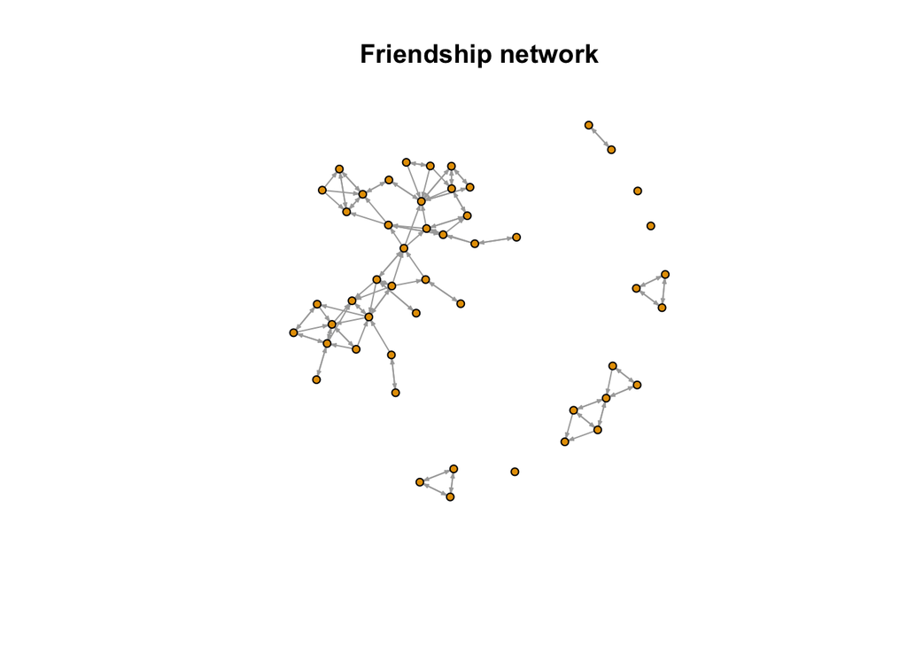

```r
# visualise graph
plot.igraph(grph,
            vertex.label='',vertex.size=4,
            edge.color='darkgrey',edge.arrow.size=.2,
            layout=layout_with_kk(grph), # other options: layout_nicely, layout_with_fr (<-- this one is furchterman reingold)
            main='Friendship network')
```

```r
# Addition of nodes' attributes (amount of sport and alcohol consumption)
# Careful to correctly match the igraph object with attribute data
V(grph)$name[1:10] # This is the order in which nodes appear in the igraph object
```

```
##  [1] "V2"  "V3"  "V4"  "V5"  "V6"  "V7"  "V8"  "V9"  "V10" "V11"
```

```r
node_sport$node_id[1:10] # This - the order in the other element
```

```
##  [1] "V2"  "V3"  "V4"  "V5"  "V6"  "V7"  "V8"  "V9"  "V10" "V11"
```

```r
# Use the match function
node_sport[match(V(grph)$name,node_sport$node_id),]$t1 # usually nodes and edges are not aligned in the same order => make sure you assign the right attributes to the right node
```

```
##  [1] 2 1 1 2 2 2 1 2 2 2 2 2 1 1 2 2 1 1 2 2 2 1 2 2 2 2 2 2 2 2 2 2 2 2 2 2 2 2
## [39] 2 2 2 1 2 1 2 1 1 2 1 2
```

```r
node_alc[match(V(grph)$name,node_alc$node_id),]$t1
```

```
##  [1] 3 2 2 2 3 4 4 4 2 4 5 5 3 3 4 4 2 4 3 2 1 3 4 3 3 4 2 2 3 1 4 4 3 2 3 4 2 3
## [39] 2 1 4 4 2 5 2 2 2 2 1 1
```

```r
V(grph)$sport <- node_sport[match(V(grph)$name,node_sport$node_id),]$t1
V(grph)$alc_con <- node_alc[match(V(grph)$name,node_alc$node_id),]$t1

# Final inspection of the igraph object
grph
```

```
## IGRAPH c565aac DN-- 50 113 --
## + attr: name (v/c), sport (v/n), alc_con (v/n)
## + edges from c565aac (vertex names):
##  [1] V2 ->V12 V2 ->V15 V3 ->V8  V3 ->V12 V4 ->V5  V4 ->V10 V5 ->V4  V5 ->V10
##  [9] V6 ->V33 V7 ->V9  V8 ->V3  V8 ->V43 V8 ->V45 V9 ->V7  V10->V4  V10->V5
## [17] V11->V12 V11->V16 V11->V34 V12->V3  V12->V16 V12->V17 V13->V8  V13->V43
## [25] V13->V45 V15->V2  V15->V11 V15->V12 V16->V11 V16->V12 V16->V17 V17->V12
## [33] V17->V16 V18->V19 V18->V20 V18->V22 V18->V23 V18->V25 V19->V20 V19->V36
## [41] V20->V12 V20->V25 V20->V27 V20->V31 V22->V23 V23->V18 V23->V22 V23->V32
## [49] V23->V35 V24->V25 V25->V18 V25->V20 V25->V22 V25->V23 V25->V24 V26->V23
## [57] V26->V32 V26->V33 V27->V8  V27->V30 V27->V45 V28->V29 V28->V30 V28->V31
## + ... omitted several edges
```

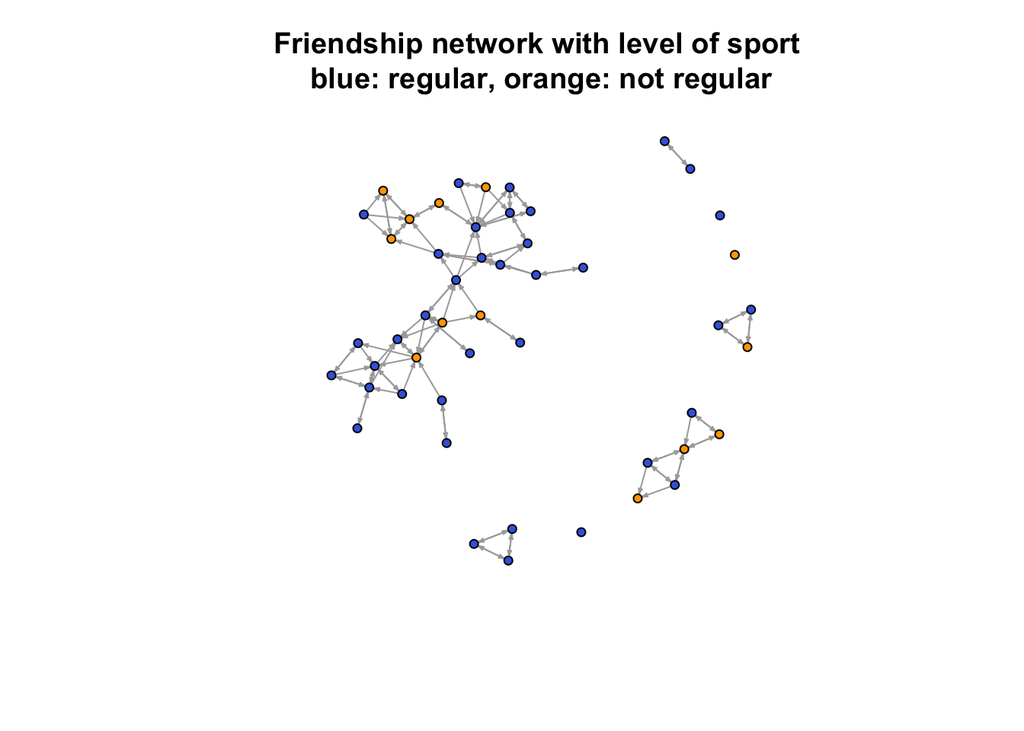

```r
# Remember nodes attributes can be visualized
# -- Sport
plot.igraph(grph,
            vertex.label='',vertex.size=4,vertex.color=ifelse(V(grph)$sport == 2,'royalblue','orange'), # 2 means regular sport
            edge.color='darkgrey',edge.arrow.size=.2,
            layout=layout_with_kk(grph),
            main='Friendship network with level of sport \nblue: regular, orange: not regular')
```

```r
# legend("bottomright", legend = c('Regular','not regular','Unknown'),
#        title = "Sport",
#        pch=21, pt.bg=c("royalblue","orange",'white'))


# -- Alcohol consumption
# Create a palette
unique(V(grph)$alc_con)
```

```
## [1] 3 2 4 5 1
```

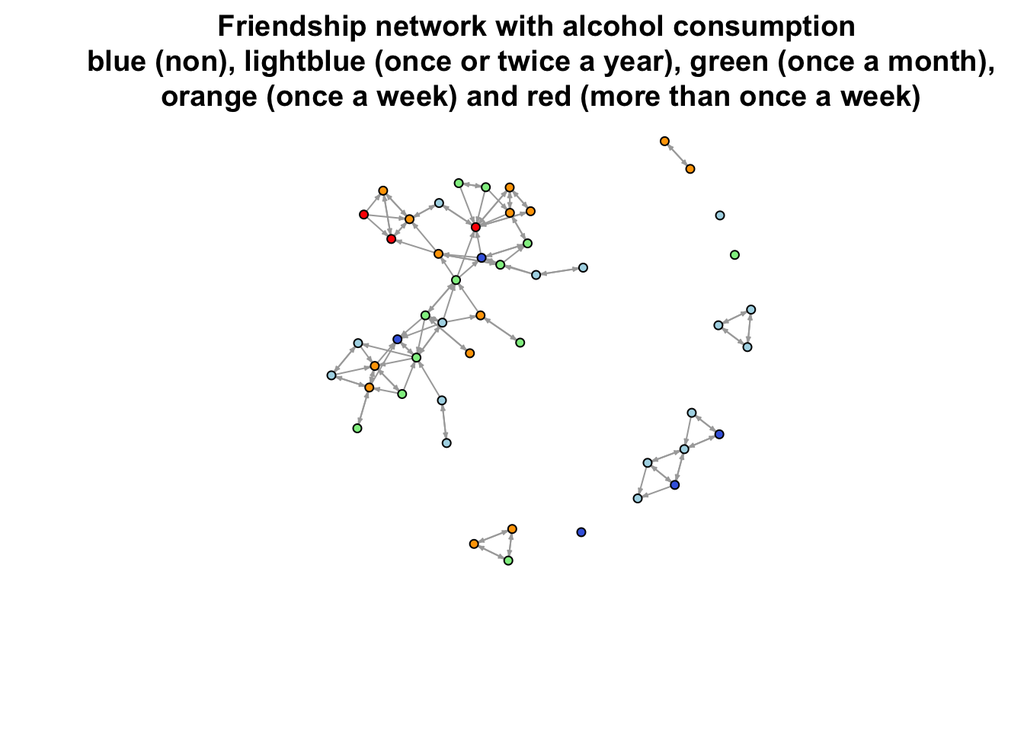

```r
pal <- c("royalblue", "lightblue", "lightgreen", "orange", "red") # Alcohol: 1 (non), 2 (once or twice a year), 3 (once a month), 4 (once a week) and 5 (more than once a week).

# Get each node's consumption behaviour
nodeCon <- V(grph)$alc_con[!duplicated(V(grph)$name)]

# Assign to the vertices as a color attribute
V(grph)$alc_color <- pal[nodeCon]

plot.igraph(grph,
            vertex.label='',
            vertex.size=4,
            vertex.color=V(grph)$alc_color, # 2 means regular sport
            edge.color='darkgrey',
            edge.arrow.size=.2,
            layout=layout_with_kk(grph),
            main='Friendship network with alcohol consumption \nblue (non), lightblue (once or twice a year), green (once a month),\norange (once a week) and red (more than once a week)')
```

```r
#[this piece of code works in the .R file, not in the .rmd one]
# Legend
# legend("bottomright",
#        legend = c("non", "once or twice a year", "once a month", "once a week", "more than once a week"),
#        title = "Alcohol consumption",
#        pch=21,
#        pt.bg=pal)
```

### Descriptives

```r
# 2) NETWORK DESCRIPTIVES AND CENTRALITY MEASURES

# 2.1) Components
igraph::components(grph)
```

```
## $membership
##  V2  V3  V4  V5  V6  V7  V8  V9 V10 V11 V12 V13 V14 V15 V16 V17 V18 V19 V20 V21
##   1   1   2   2   1   3   1   3   2   1   1   1   4   1   1   1   1   1   1   5
## V22 V23 V24 V25 V26 V27 V28 V29 V30 V31 V32 V33 V34 V35 V36 V37 V38 V39 V40 V41
##   1   1   1   1   1   1   1   1   1   1   1   1   1   1   1   6   1   6   1   7
## V42 V43 V44 V45 V46 V47 V48 V49 V50 V51
##   6   1   1   1   7   7   7   7   7   8
##
## $csize
## [1] 33  3  2  1  1  3  6  1
##
## $no
## [1] 8
```

```r
igraph::components(grph)$no # Number of components: 8
```

```
## [1] 8
```

```r
igraph::components(grph)$csize # Remember each isolate is her own component
```

```
## [1] 33  3  2  1  1  3  6  1
```

```r
igraph::components(grph)$csize[igraph::components(grph)$csize > 1]
```

```
## [1] 33  3  2  3  6
```

```r
sum(igraph::degree(grph) == 0) # isolates
```

```
## [1] 3
```

```r
# 2.2) Density
igraph::edge_density(grph) # you can also report it as a percentage, density is sensitive to size
```

```
## [1] 0.04612245
```

```r
# I personally find always more useful average degree
mean(igraph::degree(grph, mode="in")) # You can use either "in" or "out"
```

```
## [1] 2.26
```

```r
# 2.3) Reciprocity
igraph::reciprocity(grph) # in igraph, reciprocity is edgewise by default
```

```
## [1] 0.6902655
```

```r
# This is not the case in sna => gives the percentage of how many ties are reciprocal

# 2.4) Transitivity, indicates the clustering, whether there are people that form triangles
igraph::transitivity(grph)
```

```
## [1] 0.4229075
```

```r
# 2.5) Degree distribution
mean(igraph::degree(grph, mode='out'))
```

```
## [1] 2.26
```

```r
# Standard deviations
sd(igraph::degree(grph, mode='out'))
```

```
## [1] 1.19198
```

```r
sd(igraph::degree(grph, mode='in'))
```

```
## [1] 1.575449
```

```r
# Range
range(igraph::degree(grph, mode='out'))
```

```
## [1] 0 5
```

```r
range(igraph::degree(grph, mode='in'))
```

```
## [1] 0 8
```

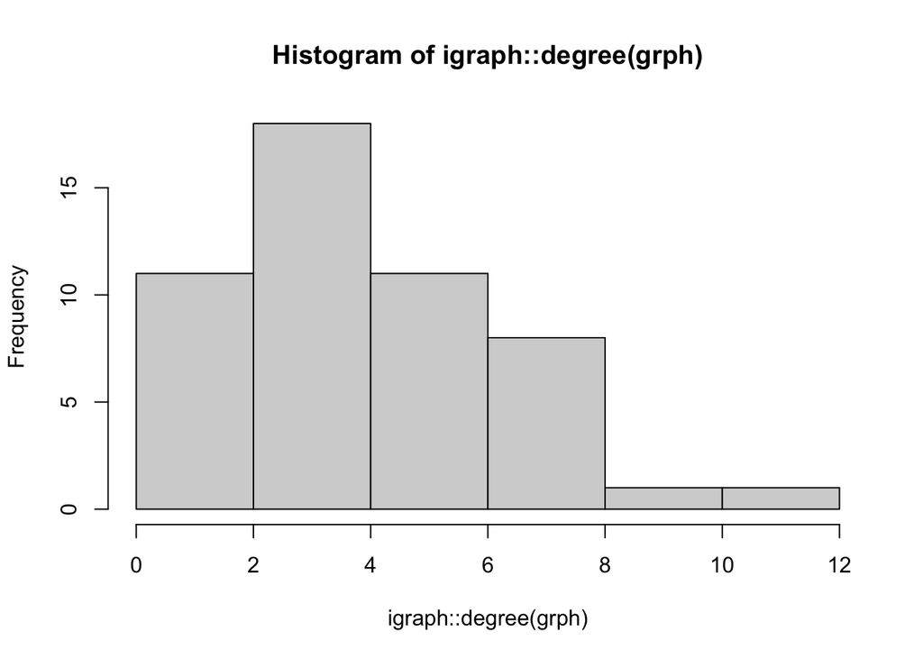

```r
# centrality measures
hist(igraph::degree(grph))
```

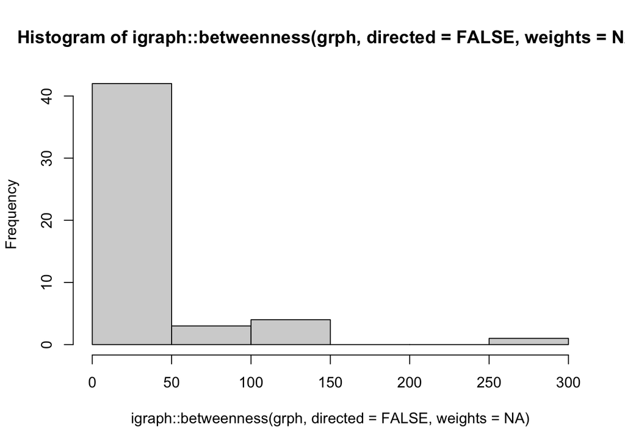

```r
hist(igraph::betweenness(grph, directed=FALSE, weights=NA))
```

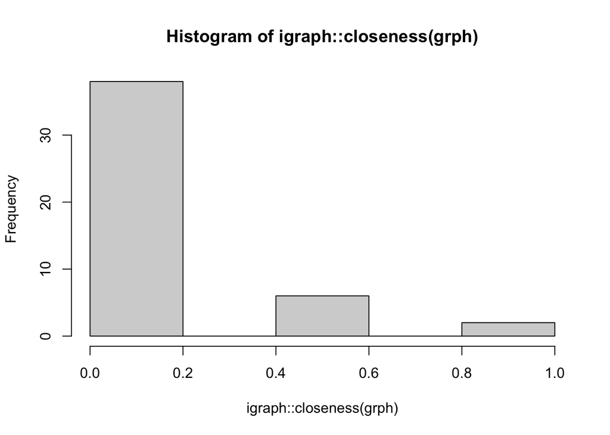

```r
hist(igraph::closeness(grph)) # here we get NANs as closeness makes only sense for connected graphs
```

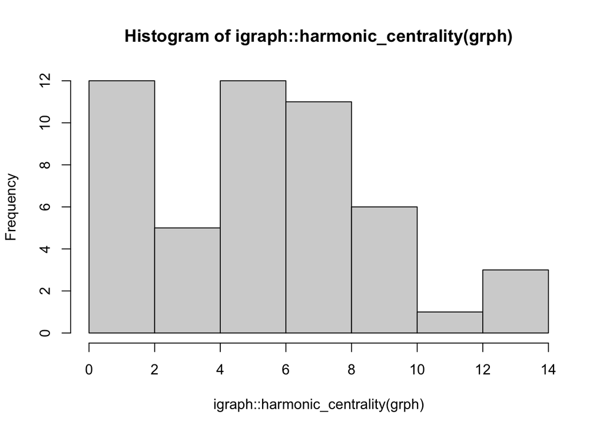

```r
hist(igraph::harmonic_centrality(grph)) # alternative for disconnected graphs
```

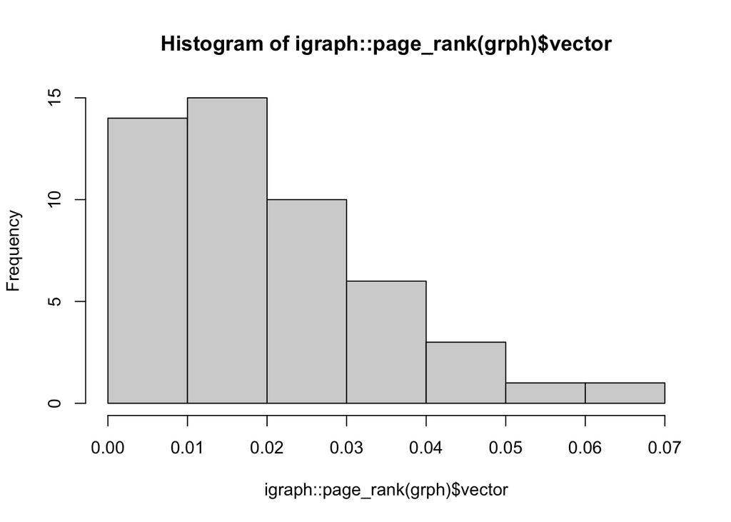

```r
hist(igraph::page_rank(grph)$vector)
```

```r
# Let's save degrees
dgr <- data.frame(personid = rep(V(grph)$name,times=2),
                  degree = c(igraph::degree(grph, mode='out'), igraph::degree(grph, mode='in')),
                  type = rep(c('outdegree','indegree'), each=vcount(grph)))
unique(dgr$type)
```

```
## [1] "outdegree" "indegree"
```

```r
head(dgr,10)
```

```
##    personid degree      type
## 1        V2      2 outdegree
## 2        V3      2 outdegree
## 3        V4      2 outdegree
## 4        V5      2 outdegree
## 5        V6      1 outdegree
## 6        V7      1 outdegree
## 7        V8      3 outdegree
## 8        V9      1 outdegree
## 9       V10      2 outdegree
## 10      V11      3 outdegree
```

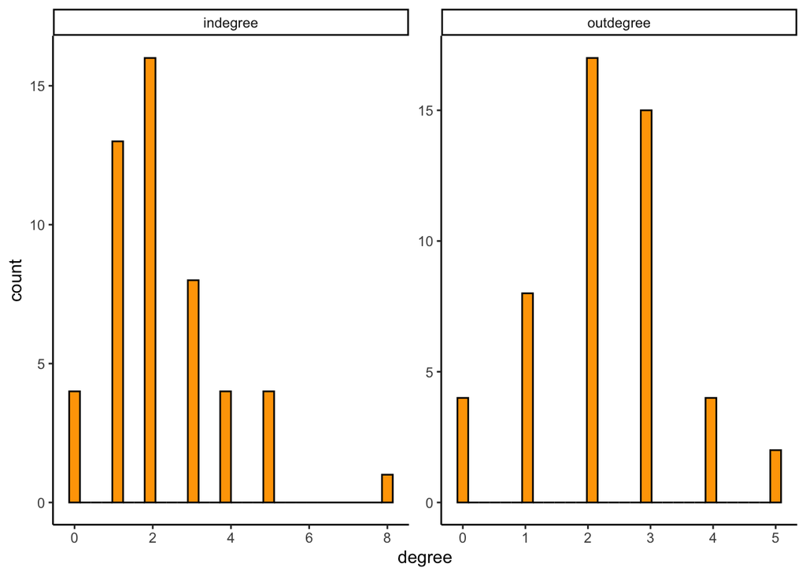

```r
# Visualization
ggplot(data=dgr) +
  geom_histogram(aes(x=degree), color='black', fill='orange') +
  facet_wrap(~type,scales='free') +
  theme_classic()
```

```r
# We can include this information to the igraph and network visualization...
V(grph)$indegree <- degree(grph,mode='in')
grph
```

```
## IGRAPH c565aac DN-- 50 113 --
## + attr: name (v/c), sport (v/n), alc_con (v/n), alc_color (v/c),
## | indegree (v/n)
## + edges from c565aac (vertex names):
##  [1] V2 ->V12 V2 ->V15 V3 ->V8  V3 ->V12 V4 ->V5  V4 ->V10 V5 ->V4  V5 ->V10
##  [9] V6 ->V33 V7 ->V9  V8 ->V3  V8 ->V43 V8 ->V45 V9 ->V7  V10->V4  V10->V5
## [17] V11->V12 V11->V16 V11->V34 V12->V3  V12->V16 V12->V17 V13->V8  V13->V43
## [25] V13->V45 V15->V2  V15->V11 V15->V12 V16->V11 V16->V12 V16->V17 V17->V12
## [33] V17->V16 V18->V19 V18->V20 V18->V22 V18->V23 V18->V25 V19->V20 V19->V36
## [41] V20->V12 V20->V25 V20->V27 V20->V31 V22->V23 V23->V18 V23->V22 V23->V32
## [49] V23->V35 V24->V25 V25->V18 V25->V20 V25->V22 V25->V23 V25->V24 V26->V23
## + ... omitted several edges
```

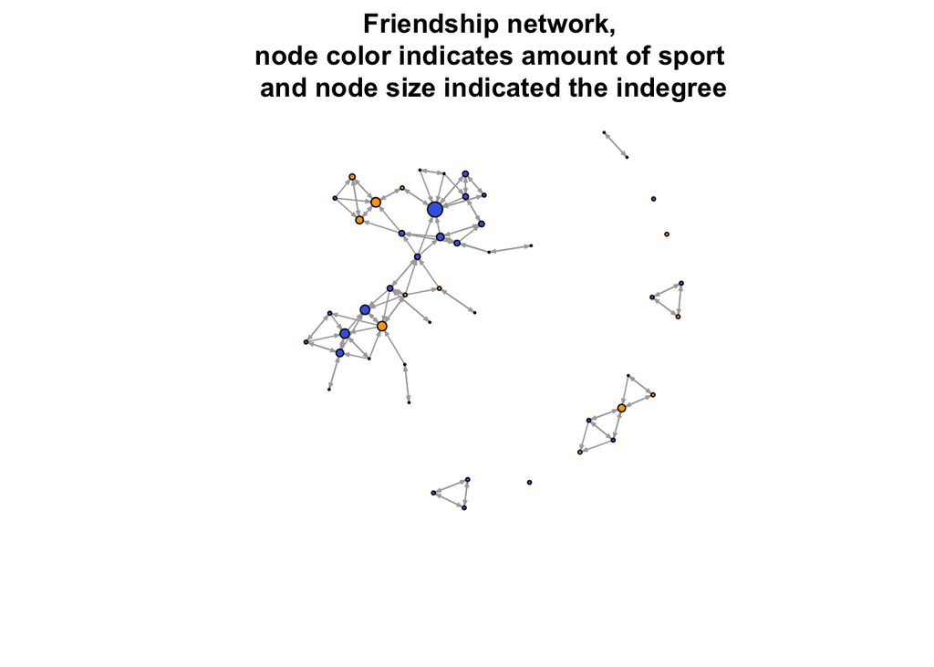

```r
plot.igraph(grph,
            vertex.label='',
            vertex.size=V(grph)$indegree,
            vertex.color=ifelse(V(grph)$sport == 2,'royalblue','orange'),
            edge.color='darkgrey',
            edge.arrow.size=.2,
            layout=layout_with_kk(grph),
            main='Friendship network, \nnode color indicates amount of sport \nand node size indicated the indegree')
```

```r
# Other types of centrality that can be obtained are, for example, betweenness, closeness
igraph::betweenness(grph)
```

```
##         V2         V3         V4         V5         V6         V7         V8
##   0.000000  50.833333   0.000000   0.000000   0.000000   0.000000  54.333333
##         V9        V10        V11        V12        V13        V14        V15
##   0.000000   0.000000  44.000000 128.833333   0.000000   0.000000   5.000000
##        V16        V17        V18        V19        V20        V21        V22
##  43.833333   0.000000 176.000000  38.000000 202.000000   0.000000  70.000000
##        V23        V24        V25        V26        V27        V28        V29
## 220.000000   0.000000  67.000000  25.666667  72.000000  12.000000   0.000000
##        V30        V31        V32        V33        V34        V35        V36
##  10.666667  79.166667  68.500000  47.500000  47.333333  10.000000   0.000000
##        V37        V38        V39        V40        V41        V42        V43
##   0.000000   3.333333   0.000000   0.000000   1.500000   0.000000   0.000000
##        V44        V45        V46        V47        V48        V49        V50
##  26.000000  11.000000   1.500000  10.000000   0.000000   0.000000   3.000000
##        V51
##   0.000000
```

```r
# 2.6) Homophily/assortativity
assortativity_degree(grph,directed=TRUE) # Assortativity degree
```

```
## [1] 0.1508808
```

```r
# Careful, positive assortativity means homophily (contrary to the EI index)
?assortativity

# Homophily by sport
isnar::assort(grph,'sport')
```

```
## [1] 0.1716821
```

```r
isnar::ei(grph,'sport') # EI index
```

```
## [1] -0.3274336
```

#### Exercise 1:

1. Find out who are the nodes with highest “indegree” and “outdegree”
2. Can you visualise your network in a way so that node color depict different centrality measures?
3. Repeat descriptive but for the final year of data collection. Which differences do you observe?

```r
# EXERCISES
# 1) Find out who are the nodes with highest "indegree" and "outdegree"

# person with highest indegree


# person with highest outdegree
```

```r
# 2) Can you visualize your network in a way so that node color depict different centrality measures?
```

```r
# your code
```

```r
# 3) Repeat the descriptive analysis but for the final year of data collection


# ties for third wave
edges_t3 <- read.csv("./s50_data/s50-network3.dat", header = FALSE, sep = " ") # adjacency matrix of the student network
edges_t3$V1 <- NULL # remove index

# Visualization

# 2.1) Components


# 2.2) Density


# 2.3) Reciprocity


# 2.4) Transitivity, indicates the clustering, whether there are people that form triangles


# 2.5) Degree distribution


# Standard deviations


# Range
```

### Transformations

```r
# 3) BASIC TRANSFORMATION

# 3.1) Dichotomization (recoding)
# Useful when valued or weighted matrices, but we aim for a simple analysis (logistic regression)
# Image, respondents were asked to assess their relationship with others on a scale 1 to 5

w.mtx <- matrix(c(0,5,2,1,2,
                  4,0,0,3,2,
                  2,2,0,4,3,
                  1,2,5,0,3,
                  1,1,5,4,0),
                nrow=5,ncol=5,byrow=TRUE,
                dimnames = list(c('A','B','C','D','E'),c('A','B','C','D','E')))
w.mtx
```

```
##   A B C D E
## A 0 5 2 1 2
## B 4 0 0 3 2
## C 2 2 0 4 3
## D 1 2 5 0 3
## E 1 1 5 4 0
```

```r
# igraph object
w.grph <- graph.adjacency(w.mtx,weighted = TRUE)
w.grph
```

```
## IGRAPH 09e078e DNW- 5 19 --
## + attr: name (v/c), weight (e/n)
## + edges from 09e078e (vertex names):
##  [1] A->B A->C A->D A->E B->A B->D B->E C->A C->B C->D C->E D->A D->B D->C D->E
## [16] E->A E->B E->C E->D
```

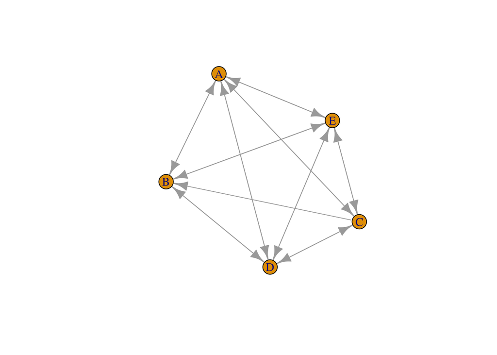

```r
plot.igraph(w.grph) # a fully connected network
```

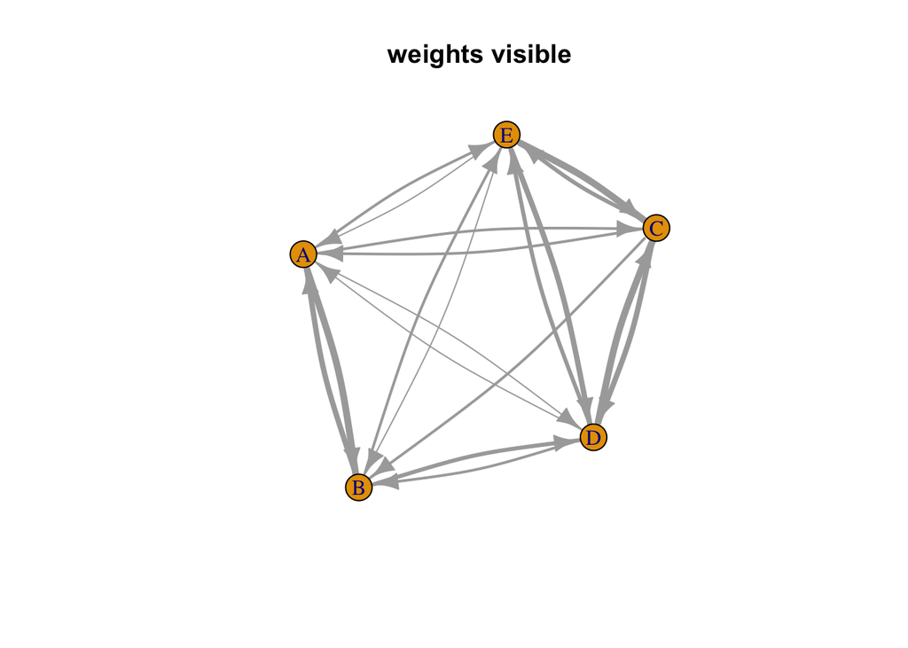

```r
plot(w.grph,
     edge.width=E(w.grph)$weight,
     main="weights visible",
     edge.curved=c(rep(0.1, 19))
     ) # With some ties stronger than others
```

```r
# You decide that at least a 4 needs to be given for a tie to exist
# Let's keep only strong ties: 4 OR 5
dich.mtx <- w.mtx
dich.mtx[dich.mtx %in% 0:3] <- 0
dich.mtx[dich.mtx %in% 4:5] <- 1
dich.mtx
```

```
##   A B C D E
## A 0 1 0 0 0
## B 1 0 0 0 0
## C 0 0 0 1 0
## D 0 0 1 0 0
## E 0 0 1 1 0
```

```r
dich.grph <- graph.adjacency(dich.mtx)
dich.grph
```

```
## IGRAPH 6bce28e DN-- 5 6 --
## + attr: name (v/c)
## + edges from 6bce28e (vertex names):
## [1] A->B B->A C->D D->C E->C E->D
```

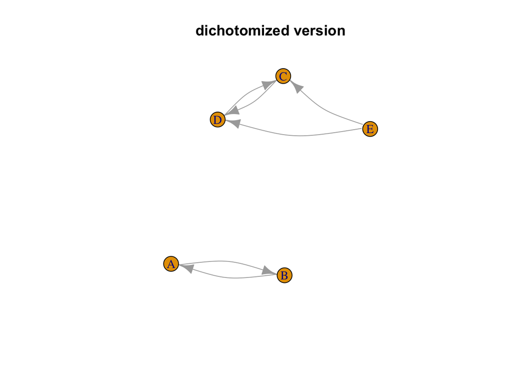

```r
plot(dich.grph,
     main='dichotomized version',
     edge.curved=c(rep(0.25, ecount(dich.grph)))
     )
```

```r
# 3.2) Transposition (shifting rows for columns)
# Reversing the direction of the ties
# Useful depending on the data collection procedure
(dich.mtx.t <- t(dich.mtx))
```

```
##   A B C D E
## A 0 1 0 0 0
## B 1 0 0 0 0
## C 0 0 0 1 1
## D 0 0 1 0 1
## E 0 0 0 0 0
```

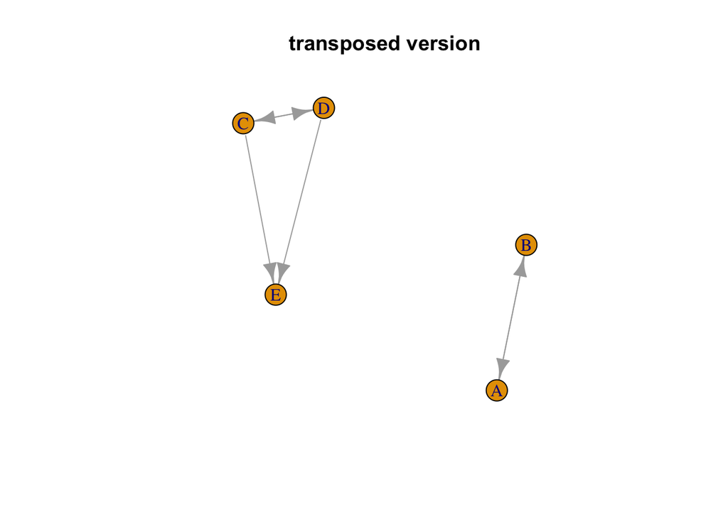

```r
dich.grph.t <- graph.adjacency(dich.mtx.t)
plot(dich.grph.t,main='transposed version')
```

```r
# 3.3) Symmetrization (from directed to undirected network)
(sym.mtx.weak <- symmetrize(dich.mtx,rule='weak')) # asymmetric ties kept (max-symmetrizing)
```

```
##      [,1] [,2] [,3] [,4] [,5]
## [1,]    0    1    0    0    0
## [2,]    1    0    0    0    0
## [3,]    0    0    0    1    1
## [4,]    0    0    1    0    1
## [5,]    0    0    1    1    0
```

```r
(sym.mtx.stro <- symmetrize(dich.mtx,rule='strong')) # only mutual ties are kept (min-symmetrizing)
```

```
##      [,1] [,2] [,3] [,4] [,5]
## [1,]    0    1    0    0    0
## [2,]    1    0    0    0    0
## [3,]    0    0    0    1    0
## [4,]    0    0    1    0    0
## [5,]    0    0    0    0    0
```

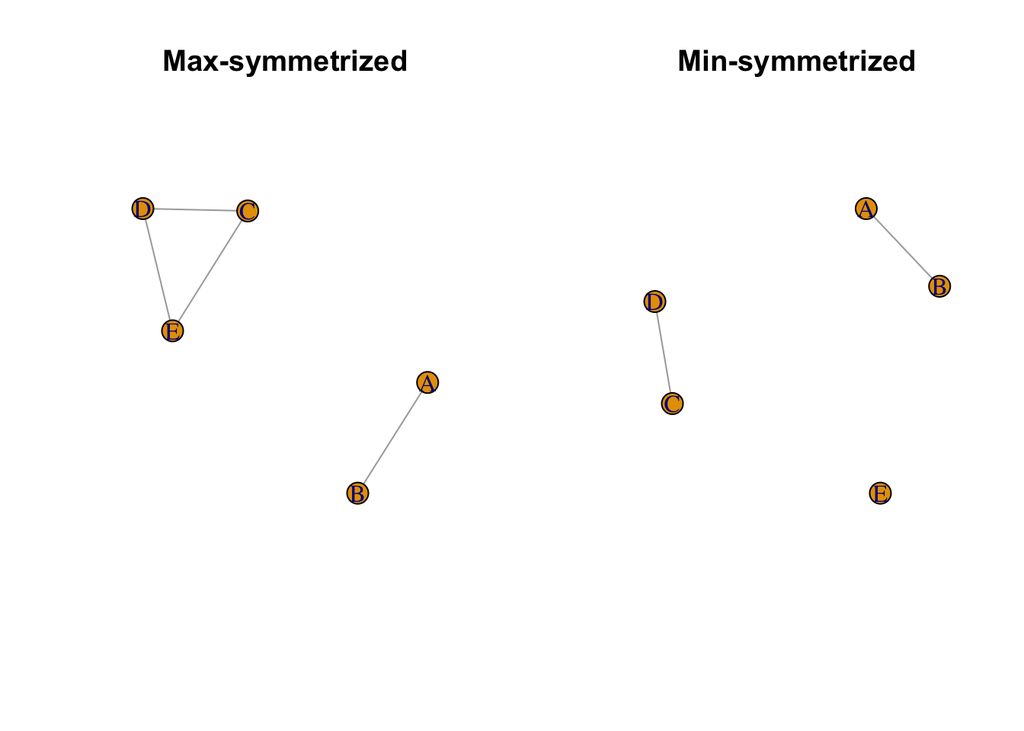

```r
# The function removes the nodes' names
dimnames(sym.mtx.weak) <- list(c('A','B','C','D','E'),c('A','B','C','D','E'))
dimnames(sym.mtx.stro) <- list(c('A','B','C','D','E'),c('A','B','C','D','E'))

# Convert into igraph objects
sym.grph.weak <- graph.adjacency(sym.mtx.weak,mode='undirected') # notice the argument: mode="undirected"
sym.grph.stro <- graph.adjacency(sym.mtx.stro,mode='undirected') # notice the argument: mode="undirected"

par(mfrow=c(1,2)) # Two plots side to side
plot.igraph(sym.grph.weak,main='Max-symmetrized')
plot.igraph(sym.grph.stro,main='Min-symmetrized')
```

```r
par(mfrow=c(1,1))
```

### Bipartite networks

```r
# 4) BIPARTITE AND MULTIPLEX NETWORKS

# 4.1) Bipartite networks (two types of nodes)
bip.mtx <- matrix(data=c(1,0,0,0,
                         1,1,0,0,
                         0,0,1,0,
                         0,1,1,0,
                         1,0,0,1,
                         1,1,0,1,
                         0,0,0,1),
                  nrow=7,ncol=4,byrow = TRUE,
                  dimnames = list(c('Agnes','Birgit','Cecilie','Dan','Elijah','Frank','Gerda'),
                                  c('Spotify','Ikea','Volvo','H&M')))
bip.mtx
```

```
##         Spotify Ikea Volvo H&M
## Agnes         1    0     0   0
## Birgit        1    1     0   0
## Cecilie       0    0     1   0
## Dan           0    1     1   0
## Elijah        1    0     0   1
## Frank         1    1     0   1
## Gerda         0    0     0   1
```

```r
# You can derive two unipartite (weighted) networks using matrix multiplication
bip.mtx %*% t(bip.mtx)
```

```
##         Agnes Birgit Cecilie Dan Elijah Frank Gerda
## Agnes       1      1       0   0      1     1     0
## Birgit      1      2       0   1      1     2     0
## Cecilie     0      0       1   1      0     0     0
## Dan         0      1       1   2      0     1     0
## Elijah      1      1       0   0      2     2     1
## Frank       1      2       0   1      2     3     1
## Gerda       0      0       0   0      1     1     1
```

```r
t(bip.mtx) %*% bip.mtx
```

```
##         Spotify Ikea Volvo H&M
## Spotify       4    2     0   2
## Ikea          2    3     1   1
## Volvo         0    1     2   0
## H&M           2    1     0   3
```

EXERCISES 1) What does the diagonal capture?

2. And the values off the diagonal?

### Multiplex networks

```r
# 4.2) Multiplex network: the special case of signed graphs (positive and negative ties)
# Say values of 1 in w.mtx means "conflictual relationship", we can derive another network (on top of dich.mtx)
neg.mtx <- w.mtx
neg.mtx[neg.mtx %in% 2:5] <- 0
neg.mtx
```

```
##   A B C D E
## A 0 0 0 1 0
## B 0 0 0 0 0
## C 0 0 0 0 0
## D 1 0 0 0 0
## E 1 1 0 0 0
```

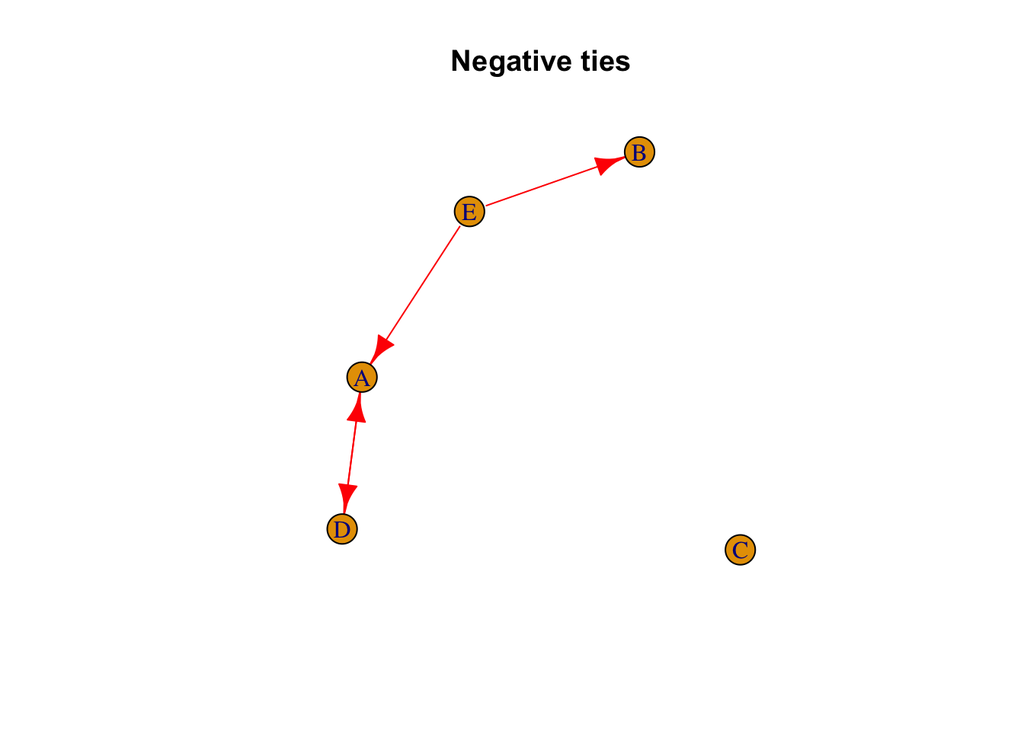

```r
# Turn into igraph format
neg.grph <- graph.adjacency(neg.mtx,mode='directed')
plot.igraph(neg.grph,edge.color='red',main='Negative ties')
```

```r
# We can merge positive and negative ties now
E(neg.grph)$sign <- 'negative'
signed.grph <- graph.union(dich.grph,neg.grph)
signed.grph
```

```
## IGRAPH 63c2f54 DN-- 5 10 --
## + attr: name (v/c), sign (e/c)
## + edges from 63c2f54 (vertex names):
##  [1] E->D E->C E->B E->A D->C D->A C->D B->A A->D A->B
```

```r
# Non-negative ties are filled with NA
E(signed.grph)$sign
```

```
##  [1] NA         NA         "negative" "negative" NA         "negative"
##  [7] NA         NA         "negative" NA
```

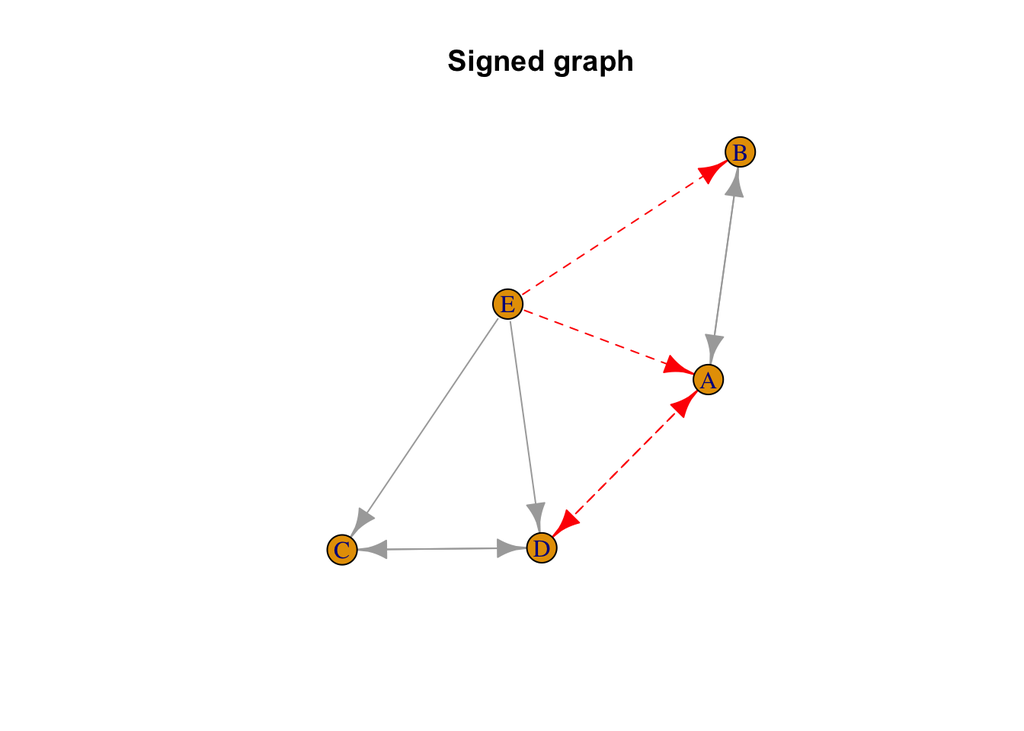

```r
E(signed.grph)$sign[is.na(E(signed.grph)$sign)] <- 'positive'

# Visualization
plot(signed.grph,
     edge.color=ifelse(E(signed.grph)$sign == 'negative','red','darkgrey'),
     edge.lty=ifelse(E(signed.grph)$sign == 'negative',2,1), # Dashed vs solid lines
     main='Signed graph')
```

```r
# legend("bottomright", legend = c('Positive tie','Negative tie'),
#        col=c('darkgrey','red'),lty=c(1,2),
#        lwd=2, ncol=1)
```

# Exercises on random graphs

### Erdős–Rényi model

The simplest version of a random graph is the Erdös-Rényi (ER) model, sometimes called the $G_{n, p}$ model. In the model, the number of nodes $n$ and the connection probability $p$ are pre-defined. Then, the model produces a graph with random connections.

Despite its simplicity, Erdös-Rényi graphs show some characteristics similar to real-world networks. As their mathematics is relatively simple, they have been studied extensively. They can serve as a null model to conduct statistical tests on networks.

Often, ER-graphs a little too simplistic to provide appropriate comparisons for empirical networks. Therefore, more sophisticated models and techniques for statistical hypothesis testing have been developed, which will be covered later.

#### Exercise 2:

Let’s construct a random graph à la Erdős–Rényi ourselves.

Below, I wrote a function that outputs a ER-graph. Try to understand each line of code. What determines the generation process?

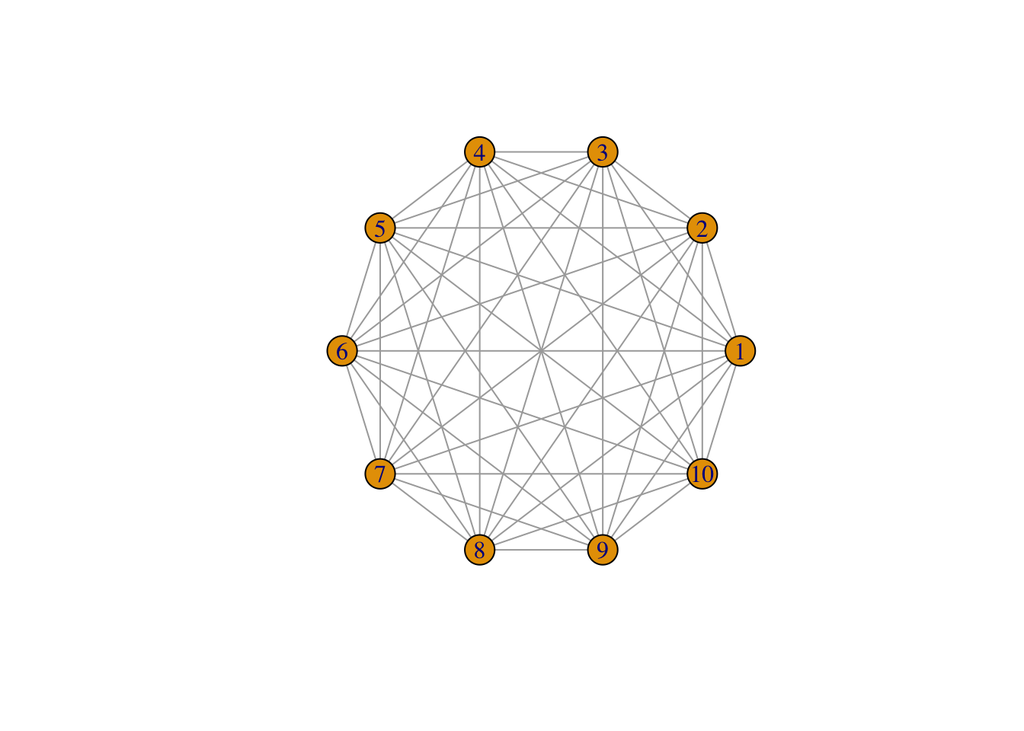

```r
generate_erdos_renyi_func <- function(number_of_nodes, p, directed = TRUE) {

  if (directed) {
    G <- make_empty_graph(n = number_of_nodes, directed = TRUE)
    edges <- permutations(number_of_nodes, 2) # for directed graph
  } else {
    G <- make_empty_graph(n = number_of_nodes, directed = FALSE)
    edges <- combinations(number_of_nodes, 2) # for undirected graph
  }

  for (i in seq(length(edges)/2)) {
    if (runif(1) <= p){
      #G <- G + edge(edges[i, 1], edges[i, 2])
      G <- G %>% add_edges(c(edges[i, 1], edges[i, 2]))
    }
  }
  return(G)
}

set.seed(123) # Set seed for reproducibility
G <- generate_erdos_renyi_func(number_of_nodes = 10, p = 1, directed = FALSE)

# Plot the graph
plot(G, layout = layout.circle, vertex.label = 1:10)
```

Erdős–Rényi networks are a good starting point in building random graphs. A surprisingly realisitic feature of them is the short average path length. In contrast to real-world networks, however, ER-graphs are characterised by a low clustering coefficient. To overcome such shortcomings, more sophisticated random graph models have been developed. The two most famous examples are the Watts-Strogatz and the Barabási-Albert model.

Both types of networks aim to provide a simple mathematical model that result in more realistic features than ER-graphs. While the Watts-Strogatz model focuses on the observation that many networks show a ‘small-world’ effect, the Barabási-Albert model proposes a preferential link attachment mechanism to create a graph with a scale-free (i.e. power law) degree distribution.

There are plenty of other models in the literature, which aim to generate realistic network properties. Among the most prominent ones is the ‘configuration model’, which is a versatile model to produce graphs with any form of degree distribution. For more details, see for example Newman (2018) Chapter 12 and Latora et al. (2018) Chapter 5.

In the following exercises, we focus on the Watts-Strogatz model and the Barabási-Albert model.

### Watts–Strogatz model

#### Exercise 3

Below you find the construction of a Watts-Strogatz model from scratch. Try to understand the code and describe in your own words what is going on. What is typical for this structure? Which mechanism do you think could potentially guide its emergence?

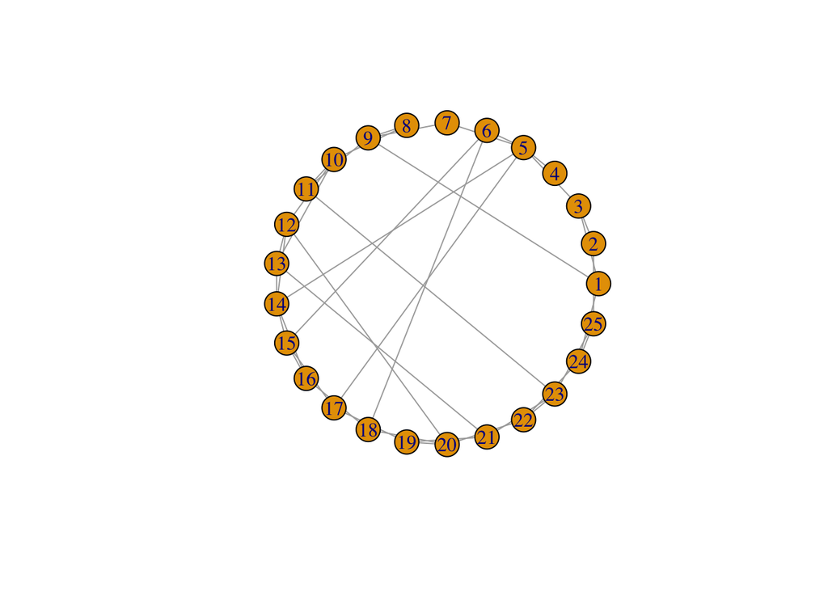

```r
# Function to create a Watts-Strogatz graph
create_watts_strogatz_graph <- function(n, k, p) {

  # Create a ring
  #g <- graph.lattice(dim = c(1, n), nei = k, directed = FALSE, circular = TRUE)

  G <- make_empty_graph(n, directed = FALSE)

  # connect k nearest neighbors
  ls_of_nodes <- seq(n)

  edges <- list()

  for (j in seq(floor(k/2)) ) {
    # Shift elements
    target_nodes <- c(tail(ls_of_nodes, -j), head(ls_of_nodes, j))
    # create edges
    more_edges <- list()
    more_edges <- cbind(ls_of_nodes, target_nodes)
    edges <- rbind(edges, more_edges)
  }

  # add edges ro graph
  G <- add_edges(G, unlist(as.vector(t(edges))))

  for (i in seq(ecount(G))) {

    u <- edges[i, 1]$ls_of_nodes
    v <- edges[i, 2]$target_nodes

    if (runif(1) <= p){
      w <- sample(ls_of_nodes, 1)

      # enforce no self-loops or multiple edges
      while ((w == u) | (are.connected(G, u, w))) {
        w <- sample(ls_of_nodes, 1)
      }

      if (degree(G, u) >= n-1) {
        break
      }

      else {
        G <- delete_edges(G, edge = c(u, v))
        G <- add_edges(G, c(u, w))
      }
    }
    }

  return(G)
}

set.seed(123) # Set seed for reproducibility
G <- create_watts_strogatz_graph(25, 5, 0.2)

# Plot the graph
plot(G, layout = layout.circle)
```

### Barabási–Albert model

Another really famous random graph is the Barabási–Albert model: It is grown by attaching new nodes each with m edges preferentially to existing nodes with high degree. You can find the documentation of the igraph function [here](https://igraph.org/r/doc/sample_pa.html).

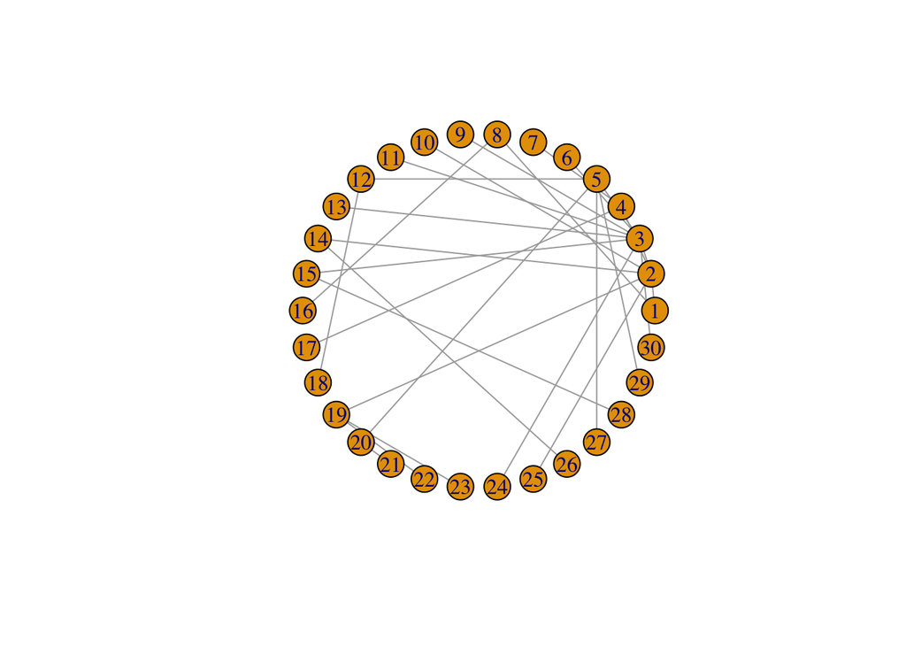

```r
G_pa <- sample_pa(30, directed = FALSE)
plot(G_pa, layout = layout.circle)
```

#### Exercise 4:

In this exercise, we will start comparing a “real-world” dataset with some of the random graph models that were introduced in this week’s lecture. The dataset contains the citation network of DBLP – a database of different scientific publications (source).

1. Generate an Erdős-Rényi graph, a Watts-Strogatz model, and a Barabási–Albert model with (approximately) the same number of nodes and edges as observed in the citation network (you can use the functions that come with the igraph package. They run faster than the self written ones).

For all four networks,

2. Plot the probability distribution (PDF) of finding a node with a certain degree over the degrees, and
3. Plot the complement of a cumulative distribution (CCDF) in log-log scale.

The CCDF displays basically the same information as the probability distribution over degrees, but instead of having the ‘probability of finding a node with its degree equal to k’ on the y-axis, the CCDF shows the ‘probability of finding a node of degree k or higher’. The CCDF is not a scattergram anymore, but a function that comes in handy if you want to fit it. Discuss the salient differences between the observed distributions for PDF and CCDF.

4. Compare and interpret.

```r
# (1)

# Function to print information about the graph
get_info <- function(graph) {
  cat("Network Summary:\n")
  cat("Number of nodes: ", vcount(graph), "\n")
  cat("Number of edges: ", ecount(graph), "\n")
  cat("Density: ", round(igraph::graph.density(graph), 5), "\n")
  cat("Average in-degree: ", round(mean(igraph::degree(graph, mode = "in")), 2), "\n")
  cat("Average out-degree: ", round(mean(igraph::degree(graph, mode = "out")), 2), "\n")
}

# Read in the citation network from a CSV file
df_cit <- read.csv("./data/cit-DBLP.csv")

# your code
```

```r
# (2)

# Function to plot the Probability Density Function (PDF) for graph degrees
```

```r
# (3)
```

#### Exercise 5:

Exercise 5: Comparison of clustering coefficients

1. Compare the clustering coefficients of all three networks. You can use igraph::transitivity(graph) to calculate them. What do your findings tell you?
2. Calculate the connection probability p for your graphs.

$p \frac{n(n-1)}{2} = m$

with p: connection probability, m: number of edges, n: number of nodes

How does the connection probability compare to the clustering coefficients?

```r
# comparison of clustering coefficients (measure of the degree to which nodes in a graph tend to cluster together)
```

#### Exercise 6:

Generate a series of Erdős-Rényi graphs with different specifications. Set the number of nodes fix to 1000 nodes, and vary p between 0.00025 and 0.0025 in steps of 0.000025. Create a plot showing the size of the largest connected component plotted against p. Can you pinpoint the phase transition?